# Data Science Term Project

Tamas Haller

March 19th 2017

## Project Subject

Almost everyone asked themselves at least once the following question: *What influences love at first site?*. In order to get some insights I downloaded a Speed dating data set from kaggle.

The data set was created by Columbia Business School professors for their paper *Gender Differences in Mate Selection: Evidence From a Speed Dating Experiment*.

The data in the data set was collected from a participants of multiple experimental speed dating events. The speed dating experiment setup was the following:

- 4 minute conversation with a participant of opposite sex
- Complete a questionnaire about the “first date”
  - Would she/he like to see the date again?
  - Rate their date on six attributes: Attractiveness, Sincerity, Intelligence, Fun, Ambition, and Shared Interests
- Switch partners
- Continue the previous steps until all the participants met

From the above data set based on the provided variable I would like to predict if there would or would not be a match between two persons. There is a match is both persons answered that they would like to see each other again. Hopefully the analysis will also uncover what are the most desirable attributes in the opposite partner.

## Data Source

I find the data under the following kaggle page: https://www.kaggle.com/annavictoria/speed-dating-experiment. The csv file itself could be downloaded from the following link: [http://www.stat.columbia.edu/~gelman/arm/examples/speed.dating/](http://www.stat.columbia.edu/%7Egelman/arm/examples/speed.dating/)

```r
# LIBRARIES
library(arm)
library(readr)
library(dplyr)
library(ggplot2)
library(pastecs)
library(DataCombine)
library(descr)
library(stargazer)
library(sandwich)
library(lmtest)
library(splines)
library(readr)
library(mfx)
library(descr)
library(pander)
library(pROC)
library(data.table)
library(rpart)
library(partykit)
library(class)
library(caret)


# CLEAR MEMORY
rm(list = ls())

# CKECK  WORKING DIRECTORY
getwd()
```

```
## [1] "C:/Users/IBM_ADMIN/Desktop"
```

```r
setwd("C:\\Users\\IBM_ADMIN\\Desktop")

# LOAD  DATA
sdd <- read.csv("Speed Dating Data.csv")
```

## Data at first sight

After checking the data at first sight and reading it’s description (which can be found at [http://www.stat.columbia.edu/~gelman/arm/examples/speed.dating/Speed%20Dating%20Data%20Key.doc](http://www.stat.columbia.edu/%7Egelman/arm/examples/speed.dating/Speed%20Dating%20Data%20Key.doc)) we can see that it contains 8378 observations and 195 variables.

```r
pander(colnames(sdd))
```

*iid*, *id*, *gender*, *idg*, *condtn*, *wave*, *round*, *position*, *positin1*, *order*, *partner*, *pid*, *match*, *int_corr*, *samerace*, *age_o*, *race_o*, *pf_o_att*, *pf_o_sin*, *pf_o_int*, *pf_o_fun*, *pf_o_amb*, *pf_o_sha*, *dec_o*, *attr_o*, *sinc_o*, *intel_o*, *fun_o*, *amb_o*, *shar_o*, *like_o*, *prob_o*, *met_o*, *age*, *field*, *field_cd*, *undergra*, *mn_sat*, *tuition*, *race*, *imprace*, *imprelig*, *from*, *zipcode*, *income*, *goal*, *date*, *go_out*, *career*, *career_c*, *sports*, *tvsports*, *exercise*, *dining*, *museums*, *art*, *hiking*, *gaming*, *clubbing*, *reading*, *tv*, *theater*, *movies*, *concerts*, *music*, *shopping*, *yoga*, *exphappy*, *expnum*, *attr1_1*, *sinc1_1*, *intel1_1*, *fun1_1*, *amb1_1*, *shar1_1*, *attr4_1*, *sinc4_1*, *intel4_1*, *fun4_1*, *amb4_1*, *shar4_1*, *attr2_1*, *sinc2_1*, *intel2_1*, *fun2_1*, *amb2_1*, *shar2_1*, *attr3_1*, *sinc3_1*, *fun3_1*, *intel3_1*, *amb3_1*, *attr5_1*, *sinc5_1*, *intel5_1*, *fun5_1*, *amb5_1*, *dec*, *attr*, *sinc*, *intel*, *fun*, *amb*, *shar*, *like*, *prob*, *met*, *match_es*, *attr1_s*, *sinc1_s*, *intel1_s*, *fun1_s*, *amb1_s*, *shar1_s*, *attr3_s*, *sinc3_s*, *intel3_s*, *fun3_s*, *amb3_s*, *satis_2*, *length*, *numdat_2*, *attr7_2*, *sinc7_2*, *intel7_2*, *fun7_2*, *amb7_2*, *shar7_2*, *attr1_2*, *sinc1_2*, *intel1_2*, *fun1_2*, *amb1_2*, *shar1_2*, *attr4_2*, *sinc4_2*, *intel4_2*, *fun4_2*, *amb4_2*, *shar4_2*, *attr2_2*, *sinc2_2*, *intel2_2*, *fun2_2*, *amb2_2*, *shar2_2*, *attr3_2*, *sinc3_2*, *intel3_2*, *fun3_2*, *amb3_2*, *attr5_2*, *sinc5_2*, *intel5_2*, *fun5_2*, *amb5_2*, *you_call*, *them_cal*, *date_3*, *numdat_3*, *num_in_3*, *attr1_3*, *sinc1_3*, *intel1_3*, *fun1_3*, *amb1_3*, *shar1_3*, *attr7_3*, *sinc7_3*, *intel7_3*, *fun7_3*, *amb7_3*, *shar7_3*, *attr4_3*, *sinc4_3*, *intel4_3*, *fun4_3*, *amb4_3*, *shar4_3*, *attr2_3*, *sinc2_3*, *intel2_3*, *fun2_3*, *amb2_3*, *shar2_3*, *attr3_3*, *sinc3_3*, *intel3_3*, *fun3_3*, *amb3_3*, *attr5_3*, *sinc5_3*, *intel5_3*, *fun5_3* and *amb5_3*

## Data cleaning

As a first step of data cleaning we will remove some of columns (variables) that are irrelevant from the perspective of our project and/or are not described by the documentation.

After deleting majority of the columns we have 17 most important variables remaining, which we will use for prediction.

```r
pander(colnames(sdd))
```

*gender*, *int_corr*, *samerace*, *age_o*, *dec_o*, *attr_o*, *sinc_o*, *intel_o*, *fun_o*, *amb_o*, *shar_o*, *age*, *field_cd*, *imprace*, *imprelig*, *exphappy* and *match*

```r
sdd <- na.omit(sdd)
```

As a last step I will omit rows with NA values and this will left us with 6838 observations and a clean data set.

```r
pander(head(sdd))
```

Table continues below

| gender | int_corr | samerace | age_o | dec_o | attr_o | sinc_o | intel_o |
| --- | --- | --- | --- | --- | --- | --- | --- |
| 0 | 0.14 | 0 | 27 | 0 | 6 | 8 | 8 |
| 0 | 0.54 | 0 | 22 | 0 | 7 | 8 | 10 |
| 0 | 0.16 | 1 | 22 | 1 | 10 | 10 | 10 |
| 0 | 0.61 | 0 | 23 | 1 | 7 | 8 | 9 |
| 0 | 0.21 | 0 | 24 | 1 | 8 | 7 | 9 |
| 0 | 0.25 | 0 | 25 | 1 | 7 | 7 | 8 |

| fun_o | amb_o | shar_o | age | field_cd | imprace | imprelig | exphappy | match |
| --- | --- | --- | --- | --- | --- | --- | --- | --- |
| 8 | 8 | 6 | 21 | 1 | 2 | 4 | 3 | 0 |
| 7 | 7 | 5 | 21 | 1 | 2 | 4 | 3 | 0 |
| 10 | 10 | 10 | 21 | 1 | 2 | 4 | 3 | 1 |
| 8 | 9 | 8 | 21 | 1 | 2 | 4 | 3 | 1 |
| 6 | 9 | 7 | 21 | 1 | 2 | 4 | 3 | 1 |
| 8 | 7 | 7 | 21 | 1 | 2 | 4 | 3 | 0 |

## Description of the final variables

### gender

Binary variable for gender, (Female=0,Male=1)

```r
pander(summary(sdd$gender))
```

| Min. | 1st Qu. | Median | Mean | 3rd Qu. | Max. |
| --- | --- | --- | --- | --- | --- |
| 0 | 0 | 0 | 0.4903 | 1 | 1 |

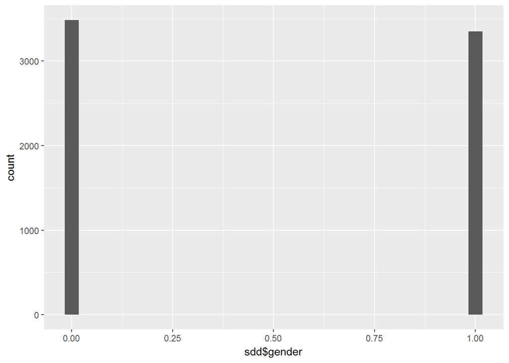

```r
qplot(sdd$gender, geom="histogram")
```

### match

Binary variable which indicates if there was a match or not (1=yes, 0=no). This is the variable that we are going to predict

```r
pander(summary(sdd$match))
```

| Min. | 1st Qu. | Median | Mean | 3rd Qu. | Max. |
| --- | --- | --- | --- | --- | --- |
| 0 | 0 | 0 | 0.1724 | 0 | 1 |

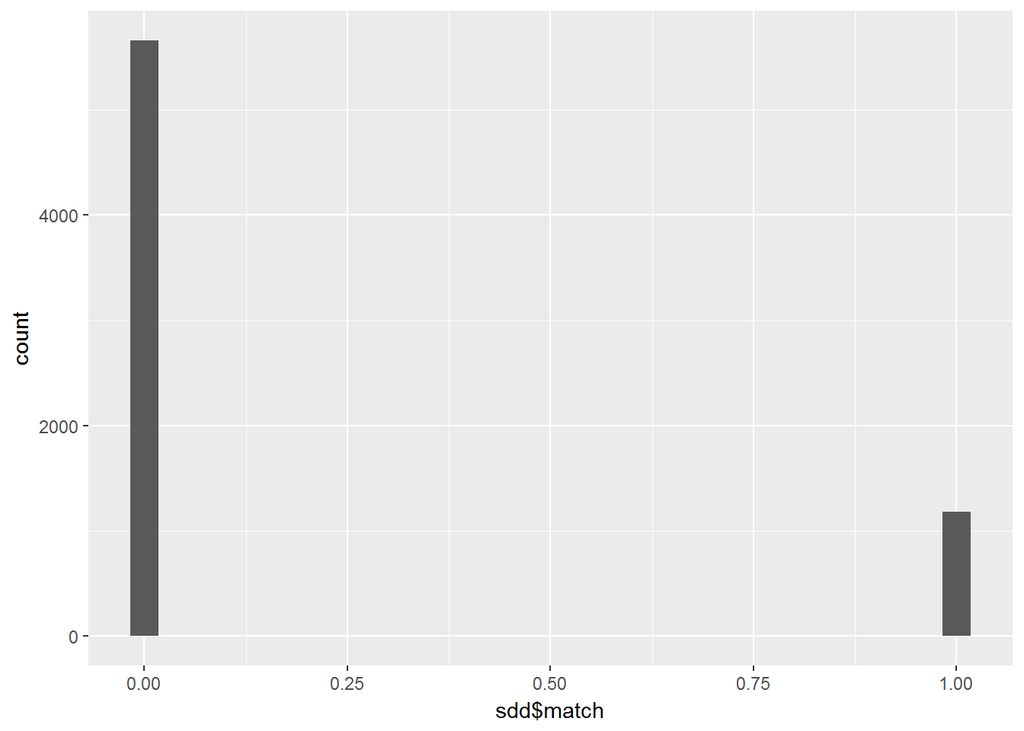

```r
qplot(sdd$match, geom="histogram")
```

### int_corr

Correlation between participants€™s and partners€™s ratings of interests

```r
pander(summary(sdd$int_corr))
```

| Min. | 1st Qu. | Median | Mean | 3rd Qu. | Max. |
| --- | --- | --- | --- | --- | --- |
| -0.83 | -0.02 | 0.21 | 0.1956 | 0.43 | 0.91 |

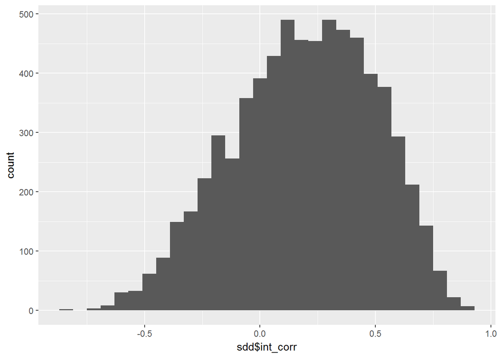

```r
qplot(sdd$int_corr, geom="histogram")
```

### samerace

Participant and the partner were the same race. (1= yes, 0=no)

```r
pander(summary(sdd$samerace))
```

| Min. | 1st Qu. | Median | Mean | 3rd Qu. | Max. |
| --- | --- | --- | --- | --- | --- |
| 0 | 0 | 0 | 0.3972 | 1 | 1 |

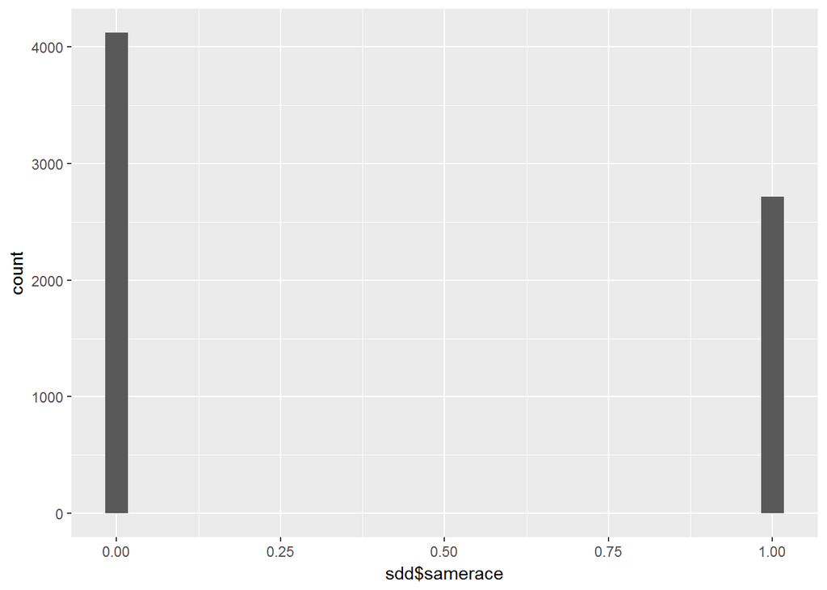

```r
qplot(sdd$samerace, geom="histogram")
```

### age_o

age of partner in years

```r
pander(summary(sdd$age_o))
```

| Min. | 1st Qu. | Median | Mean | 3rd Qu. | Max. |
| --- | --- | --- | --- | --- | --- |
| 18 | 24 | 26 | 26.25 | 28 | 55 |

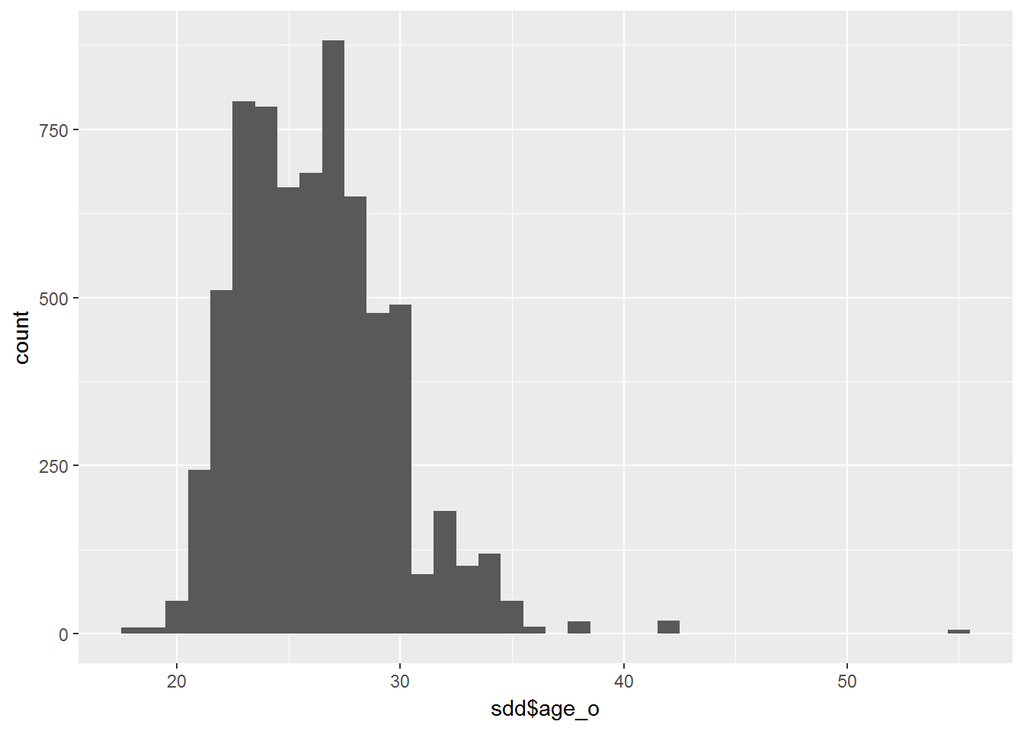

```r
qplot(sdd$age_o, geom="histogram", binwidth=1)
```

### dec_o

Decision of partner the night of event (1=yes, 0=no)

```r
pander(summary(sdd$dec_o))
```

| Min. | 1st Qu. | Median | Mean | 3rd Qu. | Max. |
| --- | --- | --- | --- | --- | --- |
| 0 | 0 | 0 | 0.432 | 1 | 1 |

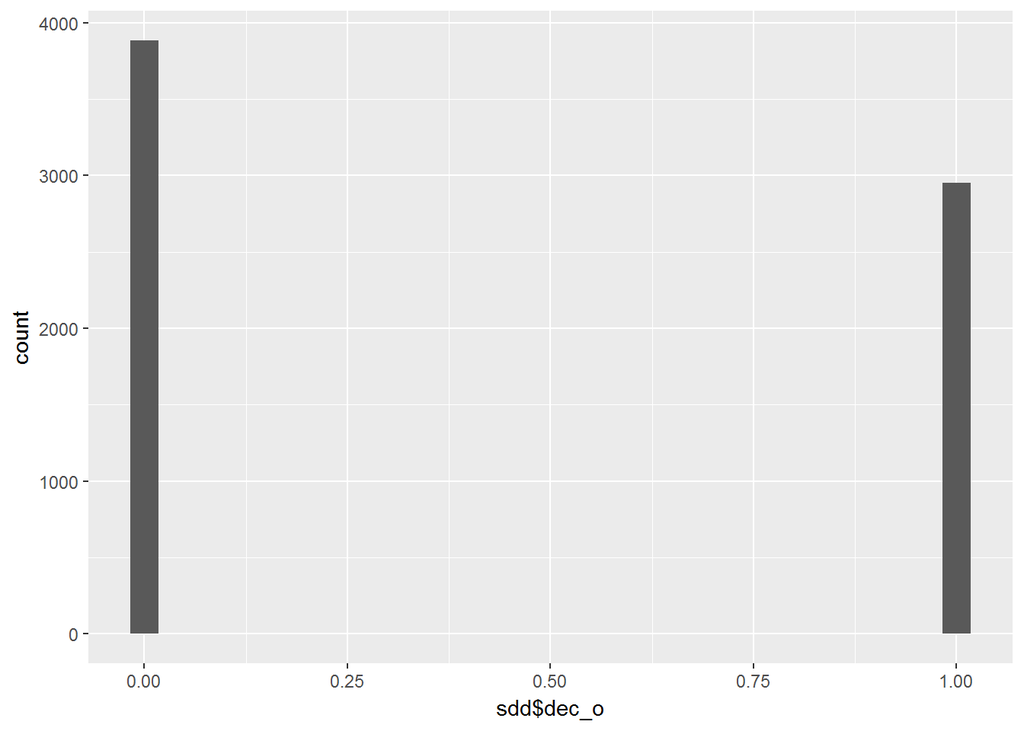

```r
qplot(sdd$dec_o, geom="histogram")
```

### attr_o, sinc_o, intel_o, fun_o, amb_o, shar_o

Rating by partner the night of the event, for all 6 attributes (Attractiveness, Sincerity, Intelligence, Fun, Ambition, and Shared Interests)

```r
pander(summary(sdd$attr_o))
```

| Min. | 1st Qu. | Median | Mean | 3rd Qu. | Max. |
| --- | --- | --- | --- | --- | --- |
| 0 | 5 | 6 | 6.188 | 8 | 10 |

```r
pander(summary(sdd$sinc_o))
```

| Min. | 1st Qu. | Median | Mean | 3rd Qu. | Max. |
| --- | --- | --- | --- | --- | --- |
| 0 | 6 | 7 | 7.161 | 8 | 10 |

```r
pander(summary(sdd$intel_o))
```

| Min. | 1st Qu. | Median | Mean | 3rd Qu. | Max. |
| --- | --- | --- | --- | --- | --- |
| 0 | 6 | 7 | 7.358 | 8 | 10 |

```r
pander(summary(sdd$fun_o))
```

| Min. | 1st Qu. | Median | Mean | 3rd Qu. | Max. |
| --- | --- | --- | --- | --- | --- |
| 0 | 5 | 7 | 6.398 | 8 | 11 |

```r
pander(summary(sdd$amb_o))
```

| Min. | 1st Qu. | Median | Mean | 3rd Qu. | Max. |
| --- | --- | --- | --- | --- | --- |
| 0 | 6 | 7 | 6.758 | 8 | 10 |

```r
pander(summary(sdd$shar_o))
```

| Min. | 1st Qu. | Median | Mean | 3rd Qu. | Max. |
| --- | --- | --- | --- | --- | --- |
| 0 | 4 | 6 | 5.461 | 7 | 10 |

### age

Age of the person in years

```r
pander(summary(sdd$age))
```

| Min. | 1st Qu. | Median | Mean | 3rd Qu. | Max. |
| --- | --- | --- | --- | --- | --- |
| 18 | 24 | 26 | 26.32 | 28 | 55 |

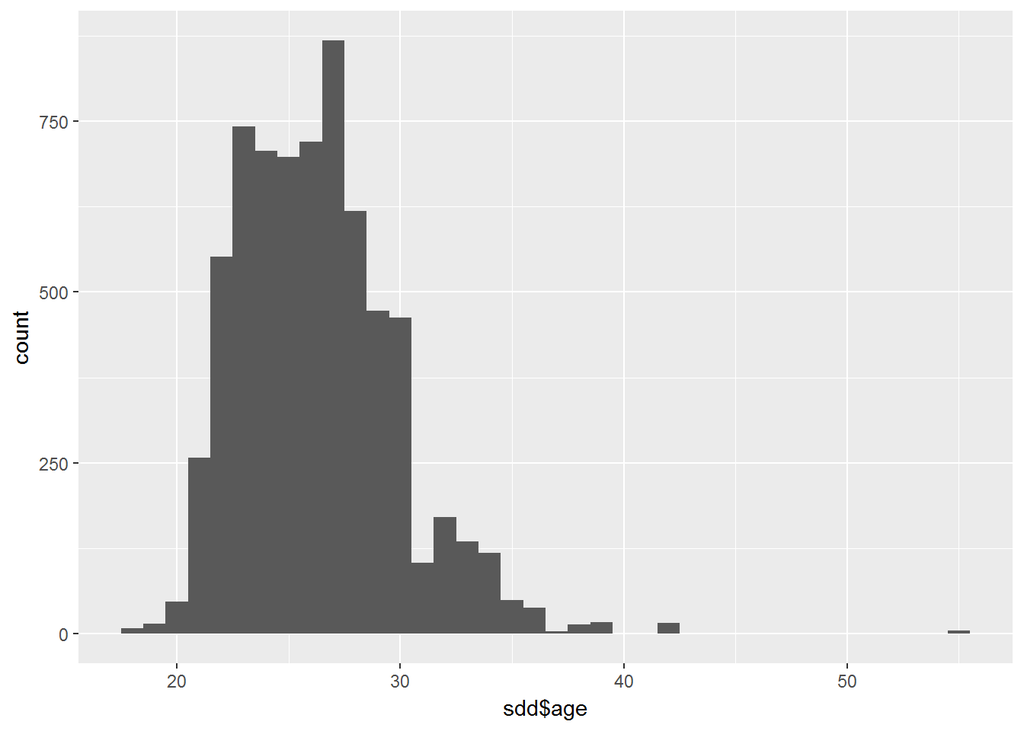

```r
qplot(sdd$age, geom="histogram", binwidth=1)
```

### field_cd

Field of study coded:

1. Law
2. Math
3. Social Science, Psychologist
4. Medical Science, Pharmaceuticals, and Bio Tech
5. Engineering
6. English/Creative Writing/ Journalism
7. History/Religion/Philosophy
8. Business/Econ/Finance
9. Education, Academia
10. Biological Sciences/Chemistry/Physics
11. Social Work
12. Undergrad/undecided
13. Political Science/International Affairs
14. Film
15. Fine Arts/Arts Administration
16. Languages
17. Architecture
18. Other

```r
pander(summary(sdd$field_cd))
```

| Min. | 1st Qu. | Median | Mean | 3rd Qu. | Max. |
| --- | --- | --- | --- | --- | --- |
| 1 | 5 | 8 | 7.686 | 10 | 18 |

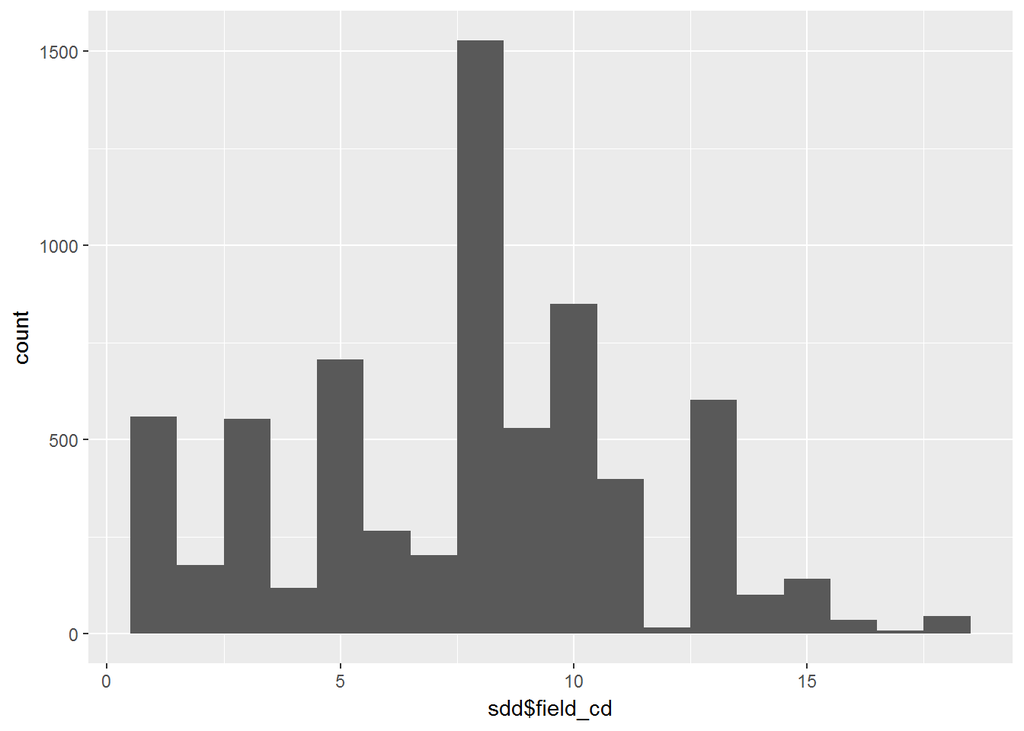

```r
qplot(sdd$field_cd, geom="histogram", binwidth=1)
```

### imprace

How important is it to the person (on a scale of 1-10) that the partner you date be of the same racial/ethnic background?

```r
pander(summary(sdd$imprace))
```

| Min. | 1st Qu. | Median | Mean | 3rd Qu. | Max. |
| --- | --- | --- | --- | --- | --- |
| 0 | 1 | 3 | 3.789 | 6 | 10 |

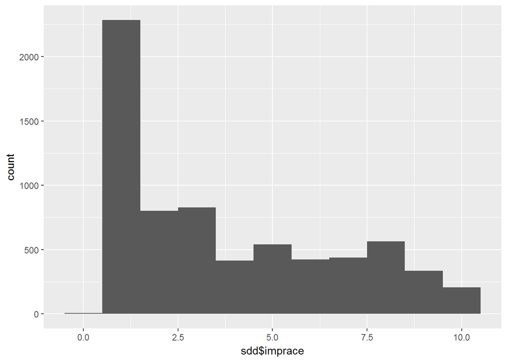

```r
qplot(sdd$imprace, geom="histogram", binwidth=1)
```

### imprelig

How important is it to the person (on a scale of 1-10) that the partner you date be of the same religious background?

```r
pander(summary(sdd$imprelig))
```

| Min. | 1st Qu. | Median | Mean | 3rd Qu. | Max. |
| --- | --- | --- | --- | --- | --- |
| 1 | 1 | 3 | 3.663 | 6 | 10 |

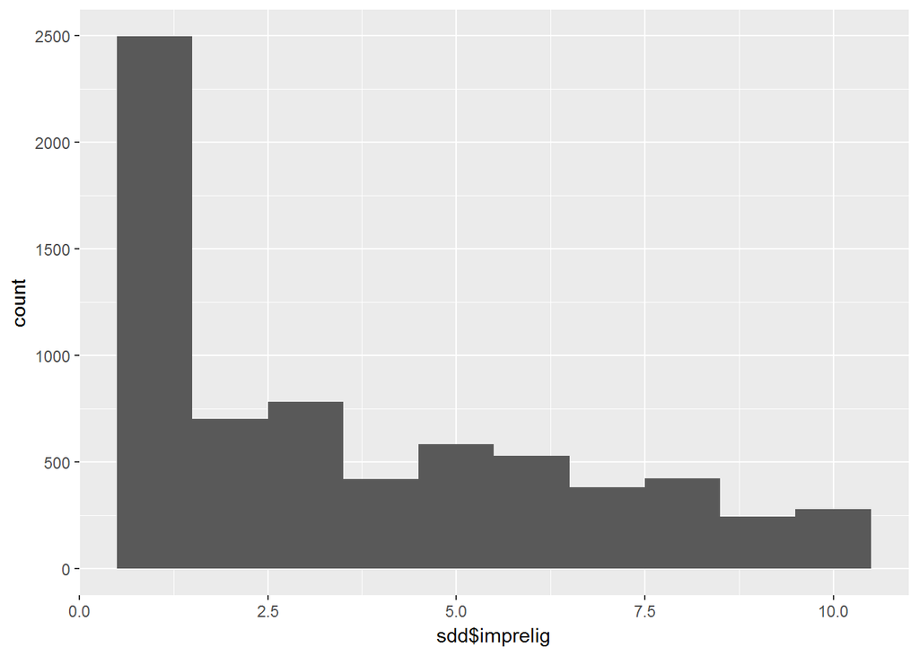

```r
qplot(sdd$imprelig, geom="histogram", binwidth=1)
```

### exphappy

Overall, on a scale of 1-10, how happy the person expect to be with the people she/he meet during the speed-dating event?

```r
pander(summary(sdd$exphappy))
```

| Min. | 1st Qu. | Median | Mean | 3rd Qu. | Max. |
| --- | --- | --- | --- | --- | --- |
| 1 | 5 | 6 | 5.524 | 7 | 10 |

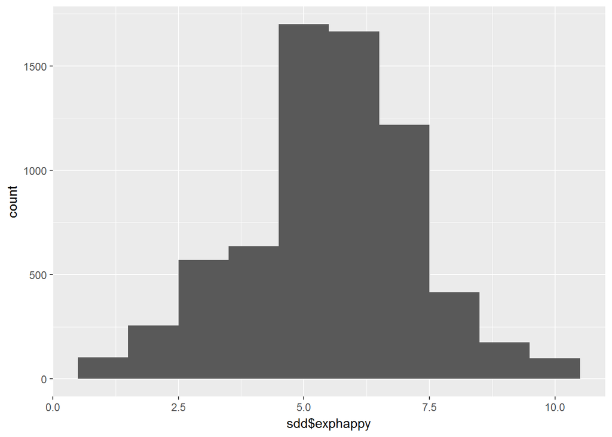

```r
qplot(sdd$exphappy, geom="histogram", binwidth=1)
```

## Few regressions, checking correlations between variables based on survey data

### Exhappy - on age

Older persons expects to be more happy with the partner met on the speed date

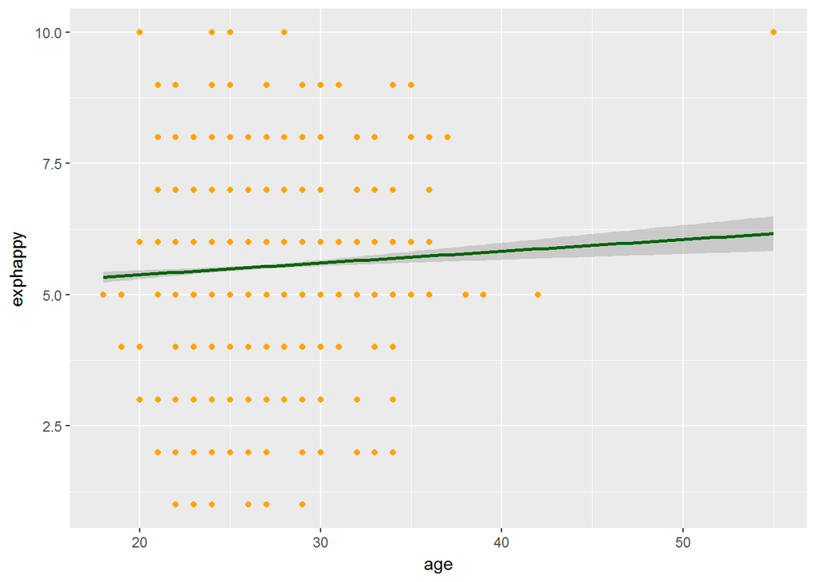

```r
ggplot(data = sdd, aes(x=age, y=exphappy)) +
  geom_point(size=1.5, colour="orange") +
  geom_smooth(method="lm", colour="darkgreen")
```

### Race importance - on age

Importance of the partner to be the same race is becoming less and less with age

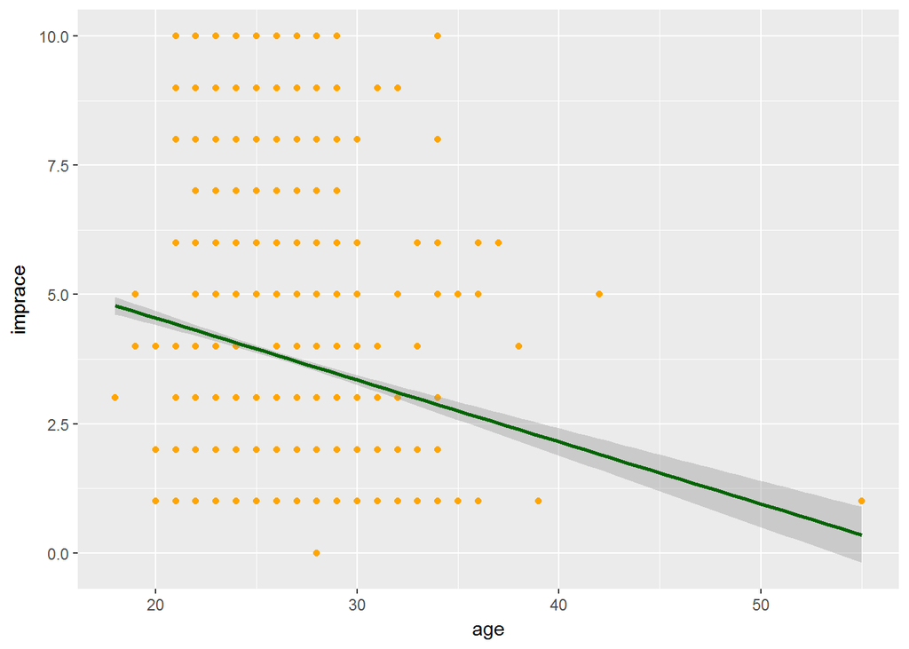

```r
ggplot(data = sdd, aes(x=age, y=imprace)) +
  geom_point(size=1.5, colour="orange") +
  geom_smooth(method="lm", colour="darkgreen")
```

### Race importance - on religion importance

For persons where the it is more important that the partner is of same religious background it is more important that they are of same racial background

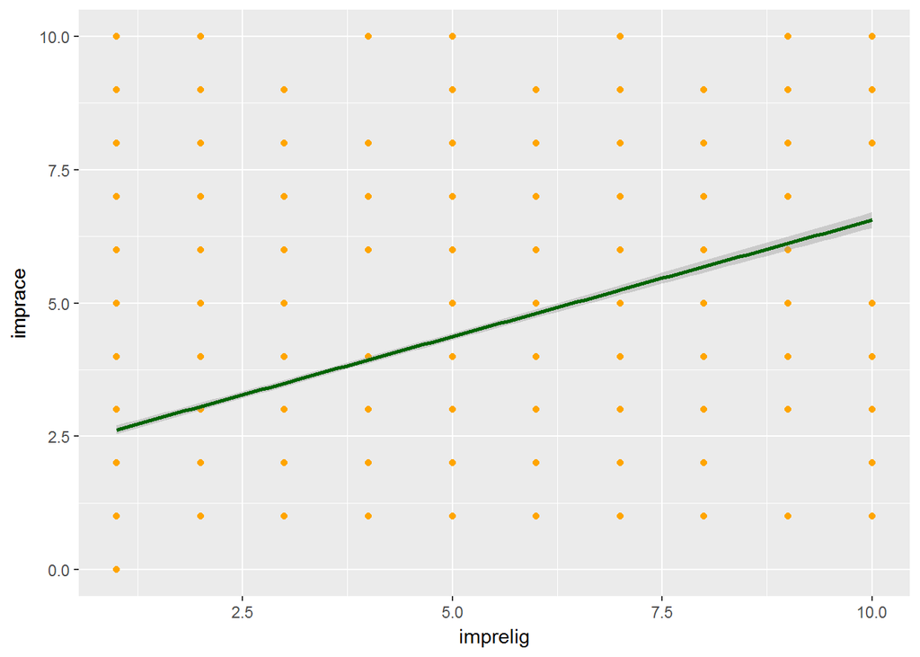

```r
ggplot(data = sdd, aes(x=imprelig, y=imprace)) +
  geom_point(size=1.5, colour="orange") +
  geom_smooth(method="lm", colour="darkgreen")
```

### Attractiveness on intelligence

More intelligent persons are more attractive on average

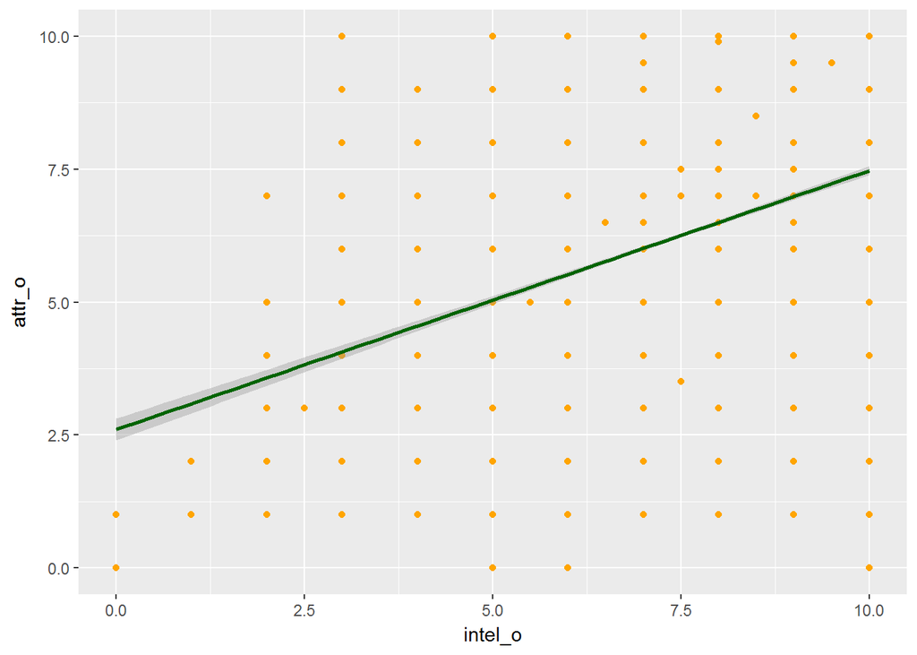

```r
ggplot(data = sdd, aes(x=intel_o, y=attr_o)) +
  geom_point(size=1.5, colour="orange") +
  geom_smooth(method="lm", colour="darkgreen")
```

### Ambition on intelligence

More ambitious persons are more intelligent on average

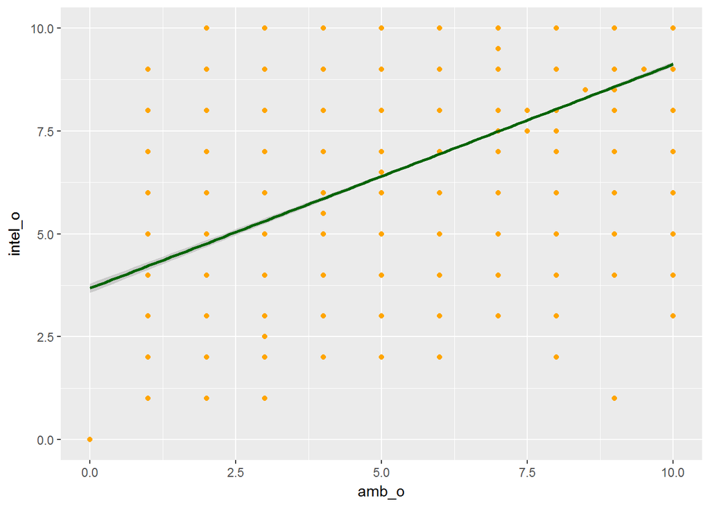

```r
ggplot(data = sdd, aes(x=amb_o, y=intel_o)) +
  geom_point(size=1.5, colour="orange") +
  geom_smooth(method="lm", colour="darkgreen")
```

## Creating train and test datasets

For modelling I will create Train and Test data sets. The data sets will be created with randomly choosing observations in the following breakdown:

- Train data set - 50% of data, used for training the models
- Test data set - 50% of data, used for model evaluation

```r
sdd <- data.table(sdd)
sdd[, rnd := runif(6838)]
setorder(sdd, rnd)
sdd
```

```
##       gender int_corr samerace age_o dec_o attr_o sinc_o intel_o fun_o
##    1:      0     0.26        1    27     1      7      7       7     7
##    2:      1     0.66        1    27     0      7      9       9     9
##    3:      1     0.14        1    29     0      6      8       8     8
##    4:      1    -0.23        0    26     1      7      8       7     8
##    5:      1    -0.22        0    30     0      5      5       5     6
##   ---
## 6834:      0     0.21        1    28     0      6      8       8     7
## 6835:      1    -0.29        1    25     0      6      8       8     6
## 6836:      0     0.30        0    27     0      4      6       8     3
## 6837:      1     0.14        1    23     1      7      7       9     8
## 6838:      0     0.22        1    27     1      9      9       9     9
##       amb_o shar_o age field_cd imprace imprelig exphappy match
##    1:     7      7  27       10       4        4        6     0
##    2:     7      5  27        7       1        1        5     0
```

[output cut: 21 more lines]

```r
sdd[, rnd := NULL]

sdd <- na.omit(sdd)

train <- sdd[1:3419]
test  <- sdd[3420:6838]
```

## Modelling

During the modelling I will try to predict if there will be a match or not based on 16 variables. First I will start with 2 simple models in R:

- K-nearest neighbors - where K=10,15,30
- Decision tree

Then I will predict matches with H2o using the following algorithms:

- Random Forest - with different setups
- GBM - with different setups

### KNN

#### 10NN

```r
for (v in c('gender', 'match', 'samerace', 'dec_o', 'field_cd')) {
    set(sdd, j = v, value = as.factor(sdd[, get(v)]))
}

res <- knn(train[, 1:16, with = FALSE], test[, 1:16, with = FALSE], train$match, k = 10)
pander(table(test$match, res))
```

|  | 0 | 1 |
| --- | --- | --- |
| **0** | 2734 | 89 |
| **1** | 505 | 91 |

```r
auc(res,test$match)
```

```
## Area under the curve: 0.6748
```

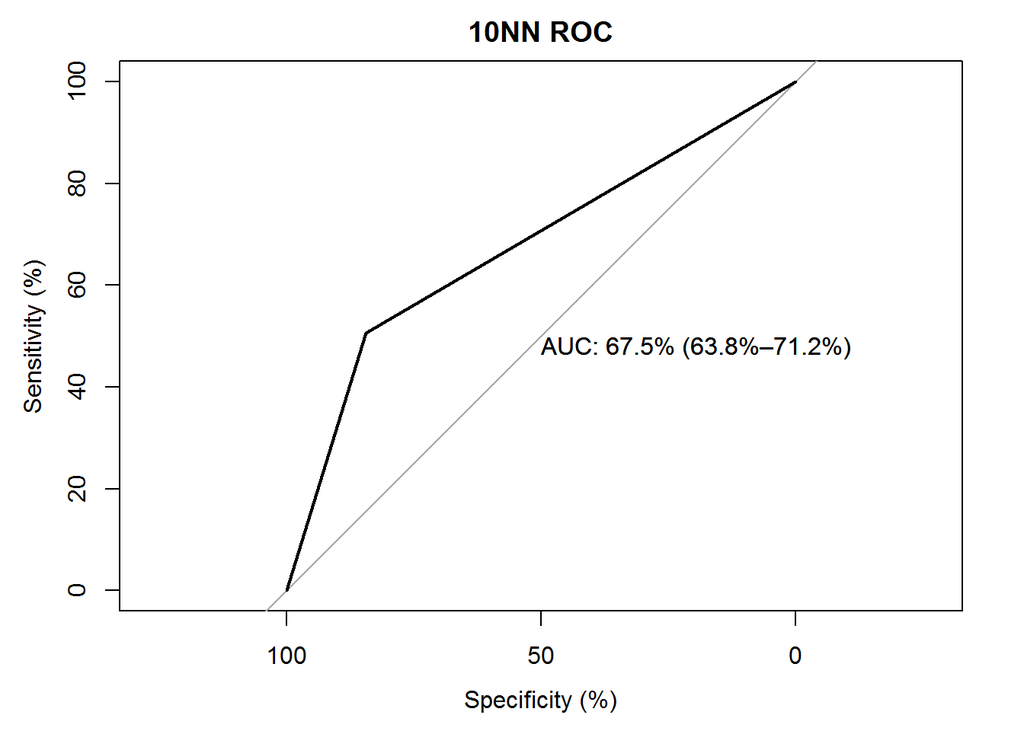

```r
plot.roc(res, test$match, main="10NN ROC", percent=TRUE, ci=TRUE, print.auc=TRUE)
```

#### 15NN

```r
res2 <- knn(train[, 1:16, with = FALSE], test[, 1:16, with = FALSE], train$match, k = 15)
pander(table(test$match, res2))
```

|  | 0 | 1 |
| --- | --- | --- |
| **0** | 2767 | 56 |
| **1** | 534 | 62 |

```r
auc(res2,test$match)
```

```
## Area under the curve: 0.6818
```

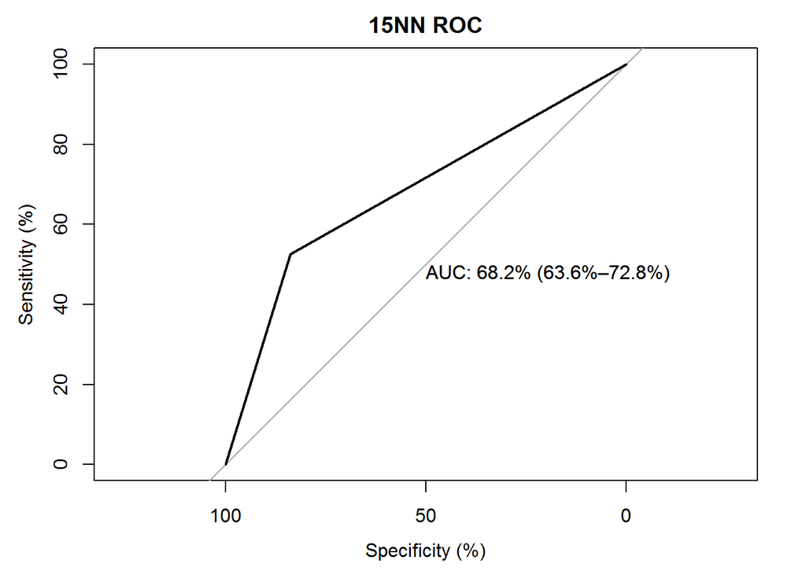

```r
plot.roc(res2, test$match, main="15NN ROC", percent=TRUE, ci=TRUE, print.auc=TRUE)
```

#### 30NN

```r
res3 <- knn(train[, 1:16, with = FALSE], test[, 1:16, with = FALSE], train$match, k = 30)
pander(table(test$match, res3))
```

|  | 0 | 1 |
| --- | --- | --- |
| **0** | 2798 | 25 |
| **1** | 569 | 27 |

```r
auc(res3,test$match)
```

```
## Area under the curve: 0.6751
```

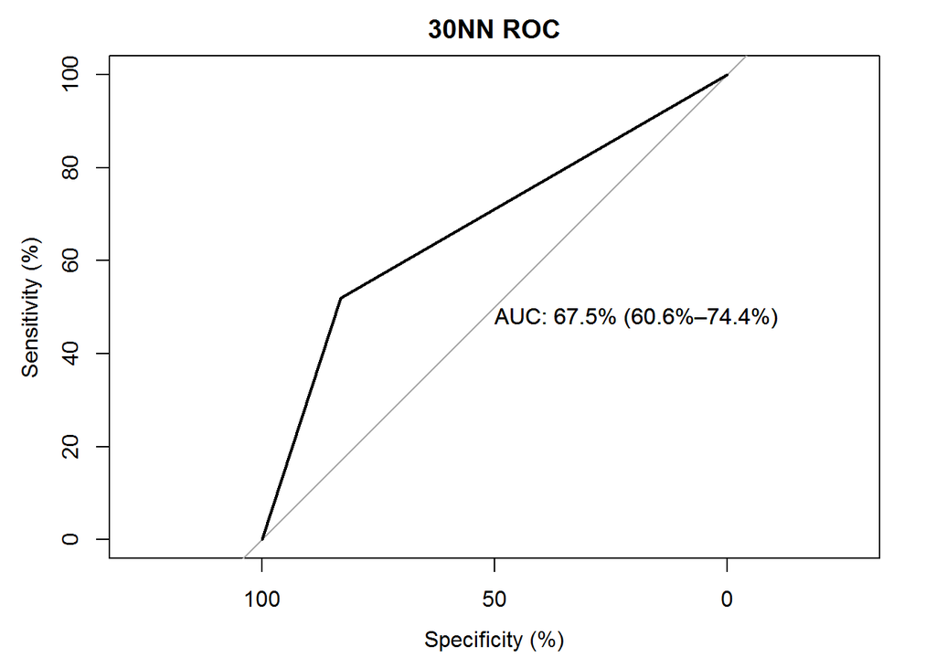

```r
plot.roc(res3, test$match, main="30NN ROC", percent=TRUE, ci=TRUE, print.auc=TRUE)
```

### Decision Tree

#### DT1

First decision tree calculated with dec_o variable. This variable shows the decision of the partner so it is logical that it will be an important predictor

```r
for (v in c('gender', 'match', 'samerace', 'dec_o', 'field_cd')) {
    set(train, j = v, value = as.factor(train[, get(v)]))
}

for (v in c('gender', 'match', 'samerace', 'dec_o', 'field_cd')) {
    set(test, j = v, value = as.factor(test[, get(v)]))
}

ct <- rpart(match ~ ., data = train)
summary(ct)
```

```
## Call:
## rpart(formula = match ~ ., data = train)
##   n= 3419
##
##          CP nsplit rel error  xerror       xstd
## 1 0.0165809      0 1.0000000 1.00000 0.03771979
## 2 0.0100000      6 0.8799314 1.03259 0.03820090
##
## Variable importance
##    dec_o   attr_o    fun_o   shar_o   sinc_o exphappy  intel_o field_cd
##       46       17       12       11        3        3        3        2
## int_corr
##        2
##
## Node number 1: 3419 observations,    complexity param=0.0165809
##   predicted class=0  expected loss=0.1705177  P(node) =1
##     class counts:  2836   583
##    probabilities: 0.829 0.171
##   left son=2 (1955 obs) right son=3 (1464 obs)
##   Primary splits:
##       dec_o   splits as  LR,         improve=265.50560, (0 missing)
##       fun_o   < 6.25   to the left,  improve= 61.39792, (0 missing)
##       shar_o  < 5.75   to the left,  improve= 56.30402, (0 missing)
##       attr_o  < 6.25   to the left,  improve= 55.91440, (0 missing)
##       intel_o < 6.5    to the left,  improve= 23.12453, (0 missing)
##   Surrogate splits:
##       attr_o  < 6.25   to the left,  agree=0.727, adj=0.362, (0 split)
##       fun_o   < 6.25   to the left,  agree=0.681, adj=0.254, (0 split)
##       shar_o  < 5.25   to the left,  agree=0.677, adj=0.247, (0 split)
##       intel_o < 7.25   to the left,  agree=0.593, adj=0.050, (0 split)
##       sinc_o  < 8.25   to the left,  agree=0.589, adj=0.041, (0 split)
##
## Node number 2: 1955 observations
##   predicted class=0  expected loss=0  P(node) =0.5718046
##     class counts:  1955     0
##    probabilities: 1.000 0.000
##
## Node number 3: 1464 observations,    complexity param=0.0165809
##   predicted class=0  expected loss=0.398224  P(node) =0.4281954
##     class counts:   881   583
```

[output cut: 88 more lines]

```
##
## Node number 59: 204 observations
##   predicted class=1  expected loss=0.4264706  P(node) =0.05966657
##     class counts:    87   117
##    probabilities: 0.426 0.574
##
## Node number 116: 296 observations
##   predicted class=0  expected loss=0.4121622  P(node) =0.08657502
##     class counts:   174   122
##    probabilities: 0.588 0.412
##
## Node number 117: 17 observations
##   predicted class=1  expected loss=0.1764706  P(node) =0.004972214
##     class counts:     3    14
##    probabilities: 0.176 0.824
```

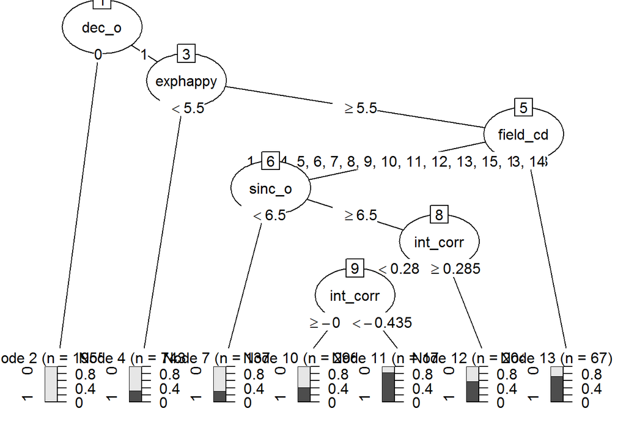

```r
plot(as.party(ct))
```

```r
res4 <- predict(ct, newdata = test, type = 'class')

pander(table(test$match, res4))
```

|  | 0 | 1 |
| --- | --- | --- |
| **0** | 2666 | 157 |
| **1** | 461 | 135 |

```r
auc(res4,as.numeric(test$match))
```

```
## Area under the curve: 0.6575
```

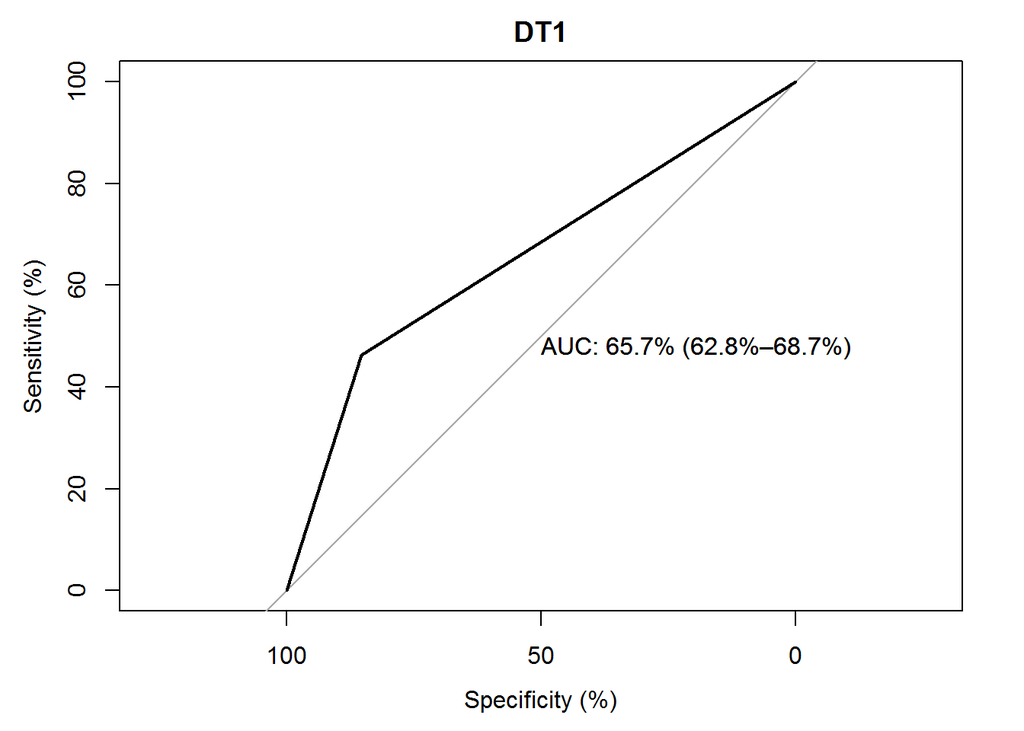

```r
plot.roc(res4,as.numeric(test$match), main="DT1", percent=TRUE, ci=TRUE, print.auc=TRUE)
```

#### DT2

Second tree was built without dec_o variable to see which other variables are important if we don’t know the decision of the partner

```r
train1<-data.table(train)
train1$dec_o<-NULL

test1<-data.table(test)
test1$dec_o<-NULL


ct1 <- rpart(match ~ ., data = train1)
summary(ct1)


plot(as.party(ct1))

res5 <- predict(ct1, newdata = test1, type = 'class')

pander(table(test1$match, res5))
auc(res5,as.numeric(test1$match))
plot.roc(res5, as.numeric(test1$match), main="DT2", percent=TRUE, ci=TRUE, print.auc=TRUE)
```

[output not shown]

## H2O setup for modelling

I used R and H2O for modelling purposes. Before start of the H2O modelling I need to setup the H2O environment as well as to convert some of the variables to factors.

```r
library(h2o)
localH2O = h2o.init()
```

[output not shown]

```r
h_train <- as.h2o(train)
h_test <- as.h2o(test)
```

### Random Forest

#### RF1

Setup is: Number of trees=500 and Maximal depth = 10

```r
{
  res_rf1 <- h2o.randomForest(x = c(1:16),
                            y = "match",
                            training_frame = h_train,
                            mtries = -1,
                            ntrees = 500,
                            max_depth = 10,
                            nbins = 20)
}
res_rf1
```

```
## Model Details:
## ==============
##
## H2OBinomialModel: drf
## Model ID:  DRF_model_R_1489980635924_1
## Model Summary:
##   number_of_trees number_of_internal_trees model_size_in_bytes min_depth
## 1             500                      500             1030398        10
##   max_depth mean_depth min_leaves max_leaves mean_leaves
## 1        10   10.00000         80        235   151.56600
##
##
## H2OBinomialMetrics: drf
## ** Reported on training data. **
## ** Metrics reported on Out-Of-Bag training samples **
##
## MSE:  0.09662123
## RMSE:  0.3108395
## LogLoss:  0.2813051
## Mean Per-Class Error:  0.1733743
## AUC:  0.8889211
## Gini:  0.7778422
##
## Confusion Matrix for F1-optimal threshold:
##           0    1    Error       Rate
## 0      2198  638 0.224965  =638/2836
## 1        71  512 0.121784    =71/583
## Totals 2269 1150 0.207371  =709/3419
##
## Maximum Metrics: Maximum metrics at their respective thresholds
##                         metric threshold    value idx
## 1                       max f1  0.289290 0.590883 227
## 2                       max f2  0.205152 0.774324 273
## 3                 max f0point5  0.415106 0.527363 141
## 4                 max accuracy  0.443030 0.842352 120
## 5                max precision  0.791099 1.000000   0
## 6                   max recall  0.048595 1.000000 330
## 7              max specificity  0.791099 1.000000   0
## 8             max absolute_mcc  0.205152 0.539290 273
## 9   max min_per_class_accuracy  0.321229 0.806065 207
## 10 max mean_per_class_accuracy  0.205152 0.851261 273
##
## Gains/Lift Table: Extract with `h2o.gainsLift(<model>, <data>)` or `h2o.gainsLift(<model>, valid=<T/F>, xval=<T/F>)`
```

```r
h2o.auc(res_rf1)
```

```
## [1] 0.8889211
```

```r
h2o.auc(h2o.performance(res_rf1, h_test))
```

```
## [1] 0.8866329
```

#### RF2

Setup is: Number of trees=500 and Maximal depth = 15

```r
{
  res_rf2 <- h2o.randomForest(x = c(1:16),
                            y = "match",
                            training_frame = h_train,
                            mtries = -1,
                            ntrees = 500,
                            max_depth = 15,
                            nbins = 20)
}
res_rf2
```

```
## Model Details:
## ==============
##
## H2OBinomialModel: drf
## Model ID:  DRF_model_R_1489980635924_98
## Model Summary:
##   number_of_trees number_of_internal_trees model_size_in_bytes min_depth
## 1             500                      500             1910500        15
##   max_depth mean_depth min_leaves max_leaves mean_leaves
## 1        15   15.00000        214        380   291.56000
##
##
## H2OBinomialMetrics: drf
## ** Reported on training data. **
## ** Metrics reported on Out-Of-Bag training samples **
##
## MSE:  0.09725413
## RMSE:  0.3118559
## LogLoss:  0.2821043
## Mean Per-Class Error:  0.1635366
## AUC:  0.8872476
## Gini:  0.7744952
##
## Confusion Matrix for F1-optimal threshold:
##           0    1    Error       Rate
## 0      2103  733 0.258463  =733/2836
## 1        40  543 0.068611    =40/583
## Totals 2143 1276 0.226089  =773/3419
##
## Maximum Metrics: Maximum metrics at their respective thresholds
##                         metric threshold    value idx
## 1                       max f1  0.234279 0.584185 271
## 2                       max f2  0.138898 0.771383 310
## 3                 max f0point5  0.422758 0.525175 154
## 4                 max accuracy  0.543757 0.842644  79
## 5                max precision  0.867626 1.000000   0
## 6                   max recall  0.072912 1.000000 332
## 7              max specificity  0.867626 1.000000   0
## 8             max absolute_mcc  0.138898 0.531316 310
## 9   max min_per_class_accuracy  0.308361 0.801481 227
## 10 max mean_per_class_accuracy  0.138898 0.848121 310
##
## Gains/Lift Table: Extract with `h2o.gainsLift(<model>, <data>)` or `h2o.gainsLift(<model>, valid=<T/F>, xval=<T/F>)`
```

```r
h2o.auc(res_rf2)
```

```
## [1] 0.8872476
```

```r
h2o.auc(h2o.performance(res_rf2, h_test))
```

```
## [1] 0.8857937
```

#### RF3

Setup is: Number of trees=1000 and Maximal depth = 15

```r
{
  res_rf3 <- h2o.randomForest(x = c(1:16),
                            y = "match",
                            training_frame = h_train,
                            mtries = -1,
                            ntrees = 1000,
                            max_depth = 15,
                            nbins = 20)
}
res_rf3
```

```
## Model Details:
## ==============
##
## H2OBinomialModel: drf
## Model ID:  DRF_model_R_1489980635924_201
## Model Summary:
##   number_of_trees number_of_internal_trees model_size_in_bytes min_depth
## 1            1000                     1000             3816675        15
##   max_depth mean_depth min_leaves max_leaves mean_leaves
## 1        15   15.00000        189        371   291.22600
##
##
## H2OBinomialMetrics: drf
## ** Reported on training data. **
## ** Metrics reported on Out-Of-Bag training samples **
##
## MSE:  0.09678137
## RMSE:  0.311097
## LogLoss:  0.281114
## Mean Per-Class Error:  0.1934319
## AUC:  0.8890031
## Gini:  0.7780061
##
## Confusion Matrix for F1-optimal threshold:
##           0   1    Error       Rate
## 0      2308 528 0.186178  =528/2836
## 1       117 466 0.200686   =117/583
## Totals 2425 994 0.188652  =645/3419
##
## Maximum Metrics: Maximum metrics at their respective thresholds
##                         metric threshold    value idx
## 1                       max f1  0.323649 0.590996 217
## 2                       max f2  0.141226 0.769537 315
## 3                 max f0point5  0.429346 0.525418 147
## 4                 max accuracy  0.531142 0.843814  86
## 5                max precision  0.875754 1.000000   0
## 6                   max recall  0.070965 1.000000 333
## 7              max specificity  0.875754 1.000000   0
## 8             max absolute_mcc  0.187292 0.532605 295
## 9   max min_per_class_accuracy  0.316391 0.806175 221
## 10 max mean_per_class_accuracy  0.181404 0.847254 298
##
## Gains/Lift Table: Extract with `h2o.gainsLift(<model>, <data>)` or `h2o.gainsLift(<model>, valid=<T/F>, xval=<T/F>)`
```

```r
h2o.auc(res_rf3)
```

```
## [1] 0.8890031
```

```r
h2o.auc(h2o.performance(res_rf3, h_test))
```

```
## [1] 0.8871355
```

### GBM

#### GBM1

Setup is: Number of trees=100 and Maximal depth = 10

```r
{
  res_gbm1 <- h2o.gbm(x = c(1:16),
                    y = "match",
                    training_frame = h_train,
                    ntrees = 100,
                    max_depth = 10,
                    learn_rate = 0.01)
}
res_gbm1
```

```
## Model Details:
## ==============
##
## H2OBinomialModel: gbm
## Model ID:  GBM_model_R_1489980635924_304
## Model Summary:
##   number_of_trees number_of_internal_trees model_size_in_bytes min_depth
## 1             100                      100              120575        10
##   max_depth mean_depth min_leaves max_leaves mean_leaves
## 1        10   10.00000         61        107    83.76000
##
##
## H2OBinomialMetrics: gbm
## ** Reported on training data. **
##
## MSE:  0.06551399
## RMSE:  0.255957
## LogLoss:  0.2334417
## Mean Per-Class Error:  0.05632858
## AUC:  0.9910085
## Gini:  0.9820169
##
## Confusion Matrix for F1-optimal threshold:
##           0   1    Error       Rate
## 0      2750  86 0.030324   =86/2836
## 1        48 535 0.082333    =48/583
## Totals 2798 621 0.039193  =134/3419
##
## Maximum Metrics: Maximum metrics at their respective thresholds
##                         metric threshold    value idx
## 1                       max f1  0.336146 0.888704 201
## 2                       max f2  0.303822 0.927393 223
## 3                 max f0point5  0.408916 0.899791 152
## 4                 max accuracy  0.336146 0.960807 201
## 5                max precision  0.709176 1.000000   0
## 6                   max recall  0.207421 1.000000 295
## 7              max specificity  0.709176 1.000000   0
## 8             max absolute_mcc  0.336146 0.865584 201
## 9   max min_per_class_accuracy  0.307639 0.954513 220
## 10 max mean_per_class_accuracy  0.303822 0.958012 223
##
## Gains/Lift Table: Extract with `h2o.gainsLift(<model>, <data>)` or `h2o.gainsLift(<model>, valid=<T/F>, xval=<T/F>)`
```

```r
h2o.auc(res_gbm1)
```

```
## [1] 0.9910085
```

```r
h2o.auc(h2o.performance(res_gbm1, h_test))
```

```
## [1] 0.8763382
```

#### GBM2

Setup is: Number of trees=500 and Maximal depth = 15

```r
{
  res_gbm2 <- h2o.gbm(x = c(1:16),
                    y = "match",
                    training_frame = h_train,
                    ntrees = 500,
                    max_depth = 15,
                    learn_rate = 0.01)
}
res_gbm2
```

```
## Model Details:
## ==============
##
## H2OBinomialModel: gbm
## Model ID:  GBM_model_R_1489980635924_420
## Model Summary:
##   number_of_trees number_of_internal_trees model_size_in_bytes min_depth
## 1             500                      500              783627        12
##   max_depth mean_depth min_leaves max_leaves mean_leaves
## 1        15   14.79800         46        243   112.30600
##
##
## H2OBinomialMetrics: gbm
## ** Reported on training data. **
##
## MSE:  0.006057073
## RMSE:  0.0778272
## LogLoss:  0.04810321
## Mean Per-Class Error:  0
## AUC:  1
## Gini:  1
##
## Confusion Matrix for F1-optimal threshold:
##           0   1    Error     Rate
## 0      2836   0 0.000000  =0/2836
## 1         0 583 0.000000   =0/583
## Totals 2836 583 0.000000  =0/3419
##
## Maximum Metrics: Maximum metrics at their respective thresholds
##                         metric threshold    value idx
## 1                       max f1  0.619672 1.000000 184
## 2                       max f2  0.619672 1.000000 184
## 3                 max f0point5  0.619672 1.000000 184
## 4                 max accuracy  0.619672 1.000000 184
## 5                max precision  0.977154 1.000000   0
## 6                   max recall  0.619672 1.000000 184
## 7              max specificity  0.977154 1.000000   0
## 8             max absolute_mcc  0.619672 1.000000 184
## 9   max min_per_class_accuracy  0.619672 1.000000 184
## 10 max mean_per_class_accuracy  0.619672 1.000000 184
##
## Gains/Lift Table: Extract with `h2o.gainsLift(<model>, <data>)` or `h2o.gainsLift(<model>, valid=<T/F>, xval=<T/F>)`
```

```r
h2o.auc(res_gbm2)
```

```
## [1] 1
```

```r
h2o.auc(h2o.performance(res_gbm2, h_test))
```

```
## [1] 0.8809878
```

#### GBM3

Setup is: Number of trees=1000 and Maximal depth = 15

```r
{
  res_gbm3 <- h2o.gbm(x = c(1:16),
                    y = "match",
                    training_frame = h_train,
                    ntrees = 1000,
                    max_depth = 15,
                    learn_rate = 0.01)
}
res_gbm3
```

```
## Model Details:
## ==============
##
## H2OBinomialModel: gbm
## Model ID:  GBM_model_R_1489980635924_538
## Model Summary:
##   number_of_trees number_of_internal_trees model_size_in_bytes min_depth
## 1            1000                     1000             2246900        12
##   max_depth mean_depth min_leaves max_leaves mean_leaves
## 1        15   14.89900         46        269   166.09300
##
##
## H2OBinomialMetrics: gbm
## ** Reported on training data. **
##
## MSE:  0.0001971834
## RMSE:  0.0140422
## LogLoss:  0.007887475
## Mean Per-Class Error:  0
## AUC:  1
## Gini:  1
##
## Confusion Matrix for F1-optimal threshold:
##           0   1    Error     Rate
## 0      2836   0 0.000000  =0/2836
## 1         0 583 0.000000   =0/583
## Totals 2836 583 0.000000  =0/3419
##
## Maximum Metrics: Maximum metrics at their respective thresholds
##                         metric threshold    value idx
## 1                       max f1  0.878385 1.000000 184
## 2                       max f2  0.878385 1.000000 184
## 3                 max f0point5  0.878385 1.000000 184
## 4                 max accuracy  0.878385 1.000000 184
## 5                max precision  0.998640 1.000000   0
## 6                   max recall  0.878385 1.000000 184
## 7              max specificity  0.998640 1.000000   0
## 8             max absolute_mcc  0.878385 1.000000 184
## 9   max min_per_class_accuracy  0.878385 1.000000 184
## 10 max mean_per_class_accuracy  0.878385 1.000000 184
##
## Gains/Lift Table: Extract with `h2o.gainsLift(<model>, <data>)` or `h2o.gainsLift(<model>, valid=<T/F>, xval=<T/F>)`
```

```r
h2o.auc(res_gbm3)
```

```
## [1] 1
```

```r
h2o.auc(h2o.performance(res_gbm3, h_test))
```

```
## [1] 0.8803444
```

## Model analysis

```r
pander(varImp(ct))
```

|  | Overall |
| --- | --- |
| **age** | 3.2 |
| **age_o** | 3.61 |
| **amb_o** | 19.25 |
| **attr_o** | 58.33 |
| **dec_o** | 265.5 |
| **exphappy** | 19.65 |
| **field_cd** | 8.558 |
| **fun_o** | 86.3 |
| **gender** | 9.469 |
| **imprelig** | 5.129 |
| **int_corr** | 15.53 |
| **intel_o** | 44.81 |
| **shar_o** | 56.3 |
| **sinc_o** | 22.92 |
| **samerace** | 0 |
| **imprace** | 0 |

The best performing GBM model was the one with 500 trees and maximal depth of 15 (GBM2). The complexity and computation time was growing from first model to third. The third model has weaker performance from the second so it is over fitted a bit. The GBM models had the highest computation time from all of the models.